# Assignment 2: Technical Report

Timur Naushirvanov

10/24/2021

## Introduction

In this report, I am presenting the results of my analysis of a market of small and mid size appartments, which can accomodate 2-6 people, in Paris. The **dependent variable** is a natural logarithm of appartments' prices.

## Data Preparation and Description

Initial dataset contains 50133 observations and 74 different variables.

According to the task, I need to focus only on small and mid sized appartements which can accomodate 2-6 people. In case of Paris, there were not very clear descriptions of different appartments types. As a result, I focused on a room type category "Entire home/apt", and then deleted from a property types categories such as rooms, cottages, houses, villas, islands, boats, caves, etc. As I result, I have got 28878 filtered observations.

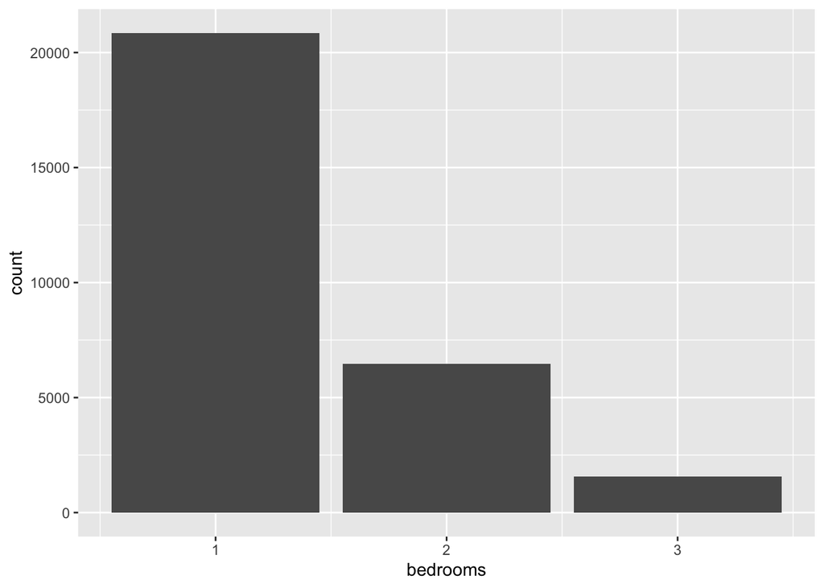

```r
## filtering data according to the task

paris_cleaned <- paris %>%
  filter(accommodates >= 2 & accommodates <= 6 & # accomodates between 2 and 6 people
          room_type == "Entire home/apt" &
           !str_detect(paris$property_type, c("condo|house|House|cottage|room|Room|Island|Barn|bed|Boat|Cave|suite|villa|bungalow|reside")) &
                         bedrooms %in% c(1, 2, 3)) # have 1 to 3 bedrooms (small & midsize appartement)

ggplot(paris_cleaned, aes(x = bedrooms)) + geom_bar()
```

After this initial filtering, I decided to look at the list of variables and how many unique variables they have. This can be useful in order to identify variables which can be automatically exluded from the analysis.

```r
unique <- c()
for (i in colnames(paris_cleaned)) {
  n <- NROW(unique(paris_cleaned[[i]]))
  unique <- append(unique, n)
}

unique_variables_n <- tibble(colnames(paris_cleaned), unique)
unique_variables_n %>%
  arrange(desc(unique)) %>%
  head(10) %>%
  kable()
```

| colnames(paris_cleaned) | unique |
| --- | --- |
| id | 28878 |
| listing_url | 28878 |
| picture_url | 28759 |
| description | 28407 |
| name | 28088 |
| amenities | 24296 |
| host_id | 24145 |
| host_url | 24145 |
| host_thumbnail_url | 24000 |
| host_picture_url | 24000 |

I have decided to delete the following variables automatically, because it is unlikely that they can be used in my further analysis: id, listing_url, picture_url, description, name, host_URL, host_id, host_url, host_thumbnail_url, host_picture_url, neighborhood_overview, host_about, license, scrape_id, neighbourhood_group_cleansed, calendar_updated, last_scraped, calculated_host_listings*, host_location, host_name, host_since, host_neighbourhood. They are usually just descriptive or irrelevant or contains all NAs.

```r
paris_cleaned <- paris_cleaned %>%
  select(-c("id", "listing_url", "picture_url", "description", "name", "host_url", "host_id", "host_url", "host_thumbnail_url", "host_picture_url","neighborhood_overview", "host_about", "license", "scrape_id", "neighbourhood_group_cleansed", "calendar_updated", "last_scraped", "host_location", "host_name", "host_since", "host_neighbourhood", "host_verifications", "neighbourhood"),
         -contains("calculated_host_listings"),
         -contains("listings_count"))
```

Then, I worked with a bathroom variables, because inititally it is shown as NAs, however, bathroom_text variables contains all main info about the number of bathrooms. I changed "half-bath" type to 0.5 and deleted irrelevant text.

```r
unique(paris_cleaned$bathrooms_text)
```

```
##  [1] "1 bath"    "2 baths"   "1.5 baths" ""          "2.5 baths" "3 baths"
##  [7] "Half-bath" "0 baths"   "3.5 baths" "5 baths"   "4.5 baths" "4 baths"
```

```r
paris_cleaned <- paris_cleaned %>%
  mutate(bathrooms_text = gsub("Half-bath|half-bath", 0.5, bathrooms_text),
         bathrooms = parse_number(bathrooms_text)) %>%
  select(-bathrooms_text)

unique(paris_cleaned$bathrooms)
```

```
##  [1] 1.0 2.0 1.5  NA 2.5 3.0 0.5 0.0 3.5 5.0 4.5 4.0
```

Now, I decided to look at the distribution of prices for its better understanding. I corrected its first (deleted dollar sign and changes the variable type), and also created its natural log. We see from graphs that prices are very skewed, and it is necessary to take its ln. Logarithm of prices has a small skew, however, I would say that it looks pretty normal. Even though it is not so important for a random forest, since I am also going to compare with other models, I prefer to use log as a dependent variable.

```r
paris_cleaned$price <- gsub("\\$", "", paris_cleaned$price)
paris_cleaned$price <- gsub(",", "", paris_cleaned$price)
paris_cleaned$price <- as.numeric(paris_cleaned$price)
paris_cleaned$lnprice <- log(paris_cleaned$price)
```

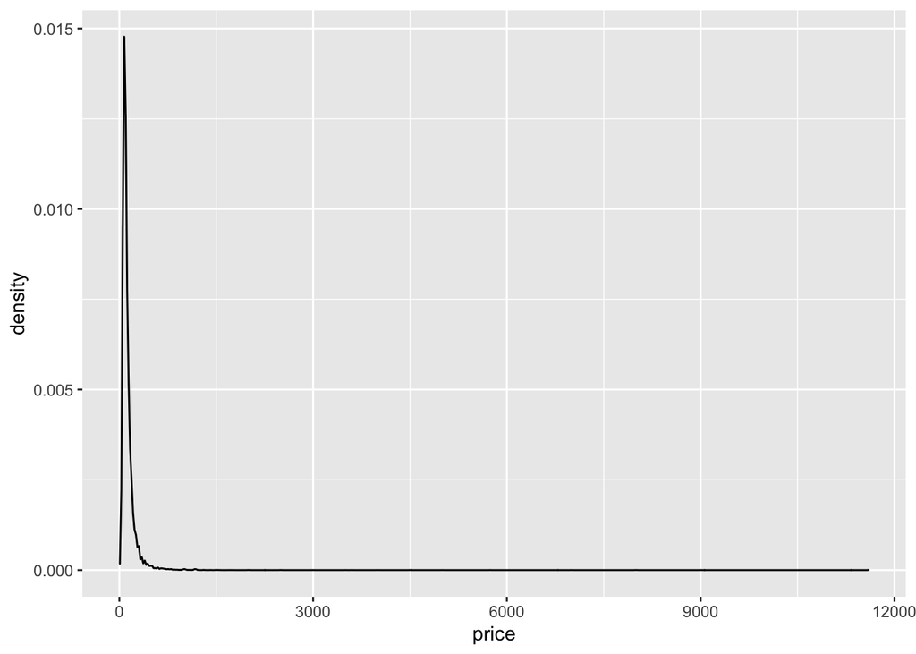

```r
ggplot(paris_cleaned, aes(x = price)) + geom_density()
```

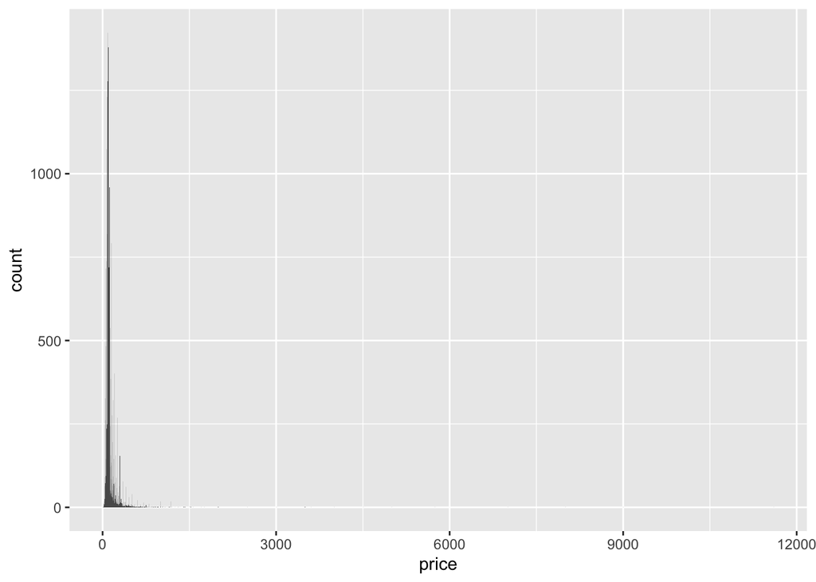

```r
ggplot(paris_cleaned, aes(x = price)) + geom_bar(width = 2)
```

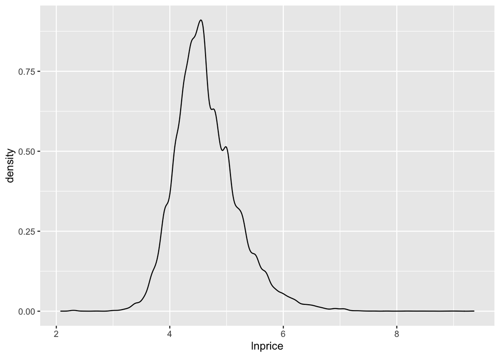

```r
ggplot(paris_cleaned, aes(x = lnprice)) + geom_density()
```

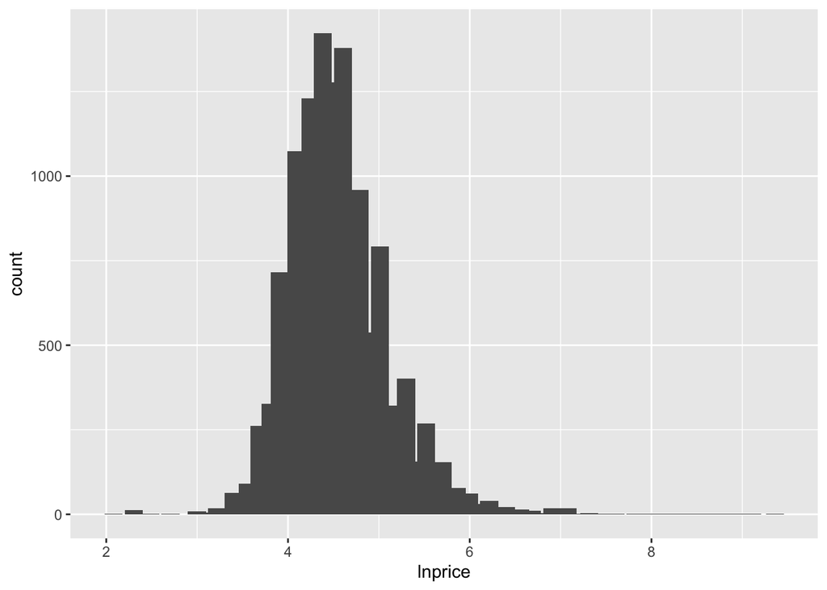

```r
ggplot(paris_cleaned, aes(x = lnprice)) + geom_bar(width = 0.2)
```

At this point, I want to look at the list of remaining variables and to pick the most appropriate for my analysis. First, let's start with numeric variables. I chose host acceptance rate (transformed it to a numeric format), created days since the first review and days since the last review, chose number of accomodates, bathrooms, beds, minimum nights, availability during the last 60 days, number of reviews and number of reviews per month, review scoring (overall rating and location). At the beginning of these variables, I added "n_" in order to work with them in an easier way.

```r
paris_cleaned$host_acceptance_rate <- as.numeric(gsub("%", "", paris_cleaned$host_acceptance_rate))
paris_cleaned <- paris_cleaned %>%
  mutate(days_since_first = as.numeric(as.Date(calendar_last_scraped,format="%Y-%m-%d") -
                                as.Date(first_review, format="%Y-%m-%d")),
         days_since_last = as.numeric(as.Date(calendar_last_scraped,format="%Y-%m-%d") -
                                         as.Date(last_review, format="%Y-%m-%d")))

quant_variables <- c("host_acceptance_rate", "accommodates", "bathrooms", "beds", "minimum_nights", "availability_60",
                     "number_of_reviews", "review_scores_rating", "reviews_per_month", "review_scores_location",
                     "days_since_first", "days_since_last")

paris_cleaned <- paris_cleaned %>%
  mutate_at(vars(quant_variables), funs("n" = as.numeric))
```

```
## Note: Using an external vector in selections is ambiguous.
## ℹ Use `all_of(quant_variables)` instead of `quant_variables` to silence this message.
## ℹ See <https://tidyselect.r-lib.org/reference/faq-external-vector.html>.
```

```r
nnames <- paris_cleaned %>%
  select(ends_with("_n")) %>%
  names()
nnames_i <- match(nnames, colnames(paris_cleaned))
colnames(paris_cleaned)[nnames_i] <- paste0("n_", quant_variables)
```

Second, I started to think about relevant dummies and factors. I chose neighbourhood_clean as a factor and superhost as a binary variable. Then, I started to work with amenities, which were initially very messy because they were not divided in different columns. The final list of unique amenities included more than 1200 names, so I picked several as a dummies that may be relevant for prices: Wi-Fi, TV, Coffee Machine, Netflix, Breakfast, Free parking, Cleaning products, Bed linens, Dedicated workspace.

```r
paris_cleaned <- paris_cleaned %>%
  mutate(f_neighbourhood_clean = factor(paris_cleaned$neighbourhood_cleansed),
         b_superhost = factor(ifelse(paris_cleaned$host_is_superhost == 't', 1, 0)))

# working with amenities
paris_cleaned$amenities <- gsub("\"", "", paris_cleaned$amenities)
paris_cleaned$amenities <- gsub("\\[|\\]", "", paris_cleaned$amenities)
paris_cleaned$amenities <- gsub("\\[|\\]", "", paris_cleaned$amenities)

# list of unique amenities
amenities <- c()
for (i in paris_cleaned$amenities) {
  splitted <- str_split_fixed(i, ",", n = Inf)
  for (amenity in splitted) {
    if (trimws(amenity) %in% amenities) {
      next
    } else {amenities <- append(amenities, trimws(amenity))}
  }
}

amenities <- gsub("[()]", "", amenities)

amenities <- tolower(amenities)
paris_cleaned$amenities <- tolower(paris_cleaned$amenities)

to_dummies <- paris_cleaned %>% select(host_response_rate, amenities)

# calculating the number of each amenity
n_amenities <- c()
for (i in amenities) {
  n_amenities <- append(n_amenities, sum(str_detect(to_dummies$amenities, i)))
  }


# showing all amenities and their number of mentions
dt <- data.table(amenities, n_amenities)
dt <- dt %>%
  filter(n_amenities >= 1) %>%
  arrange(desc(n_amenities))
head(dt, 15)
```

| amenities | n_amenities |
| --- | --- |
|  | 28876 |
| kitchen | 28272 |
| wifi | 27597 |
| heating | 27157 |
| essentials | 26869 |
| long term stays allowed | 25903 |
| washer | 25328 |
| dryer | 22923 |
| iron | 21457 |
| smoke alarm | 21252 |

[output cut: 5 more lines]

```r
paris_cleaned <- paris_cleaned %>%
  mutate(b_wifi = factor(ifelse(str_detect(paris_cleaned$amenities, "wifi"), 1, 0)),
         b_tv = factor(ifelse(str_detect(paris_cleaned$amenities, "tv"), 1, 0)),
         b_coffee = factor(ifelse(str_detect(paris_cleaned$amenities, "coffee"), 1, 0)),
         b_netflix = factor(ifelse(str_detect(paris_cleaned$amenities, "netflix"), 1, 0)),
         b_breakfast = factor(ifelse(str_detect(paris_cleaned$amenities, "breakfast"), 1, 0)),
         b_freepark = factor(ifelse(str_detect(paris_cleaned$amenities, "free parking"), 1, 0)),
         b_cleanprod = factor(ifelse(str_detect(paris_cleaned$amenities, "cleaning products"), 1, 0)),
         b_bedlinens = factor(ifelse(str_detect(paris_cleaned$amenities, "bed linens"), 1, 0)),
         b_workspace = factor(ifelse(str_detect(paris_cleaned$amenities, "dedicated workspace"), 1, 0)))
```

Now, I picked all relevant variables and want to finalise them in a separated working dataset.

```r
final_data <- paris_cleaned %>%
  select(price, lnprice, starts_with(c("n_", "b_", "f_")))
```

At this point, it is important to look at NAs.

```r
to_filter <- sapply(final_data, function(x) sum(is.na(x)))
to_filter[to_filter > 0]
```

```
##   n_host_acceptance_rate              n_bathrooms                   n_beds
##                    15204                       17                       79
##   n_review_scores_rating      n_reviews_per_month n_review_scores_location
##                     6135                     6135                     6515
##       n_days_since_first        n_days_since_last
##                     6135                     6135
```

```r
summary(final_data$n_bathrooms)
```

```
##    Min. 1st Qu.  Median    Mean 3rd Qu.    Max.    NA's
##   0.000   1.000   1.000   1.124   1.000   5.000      17
```

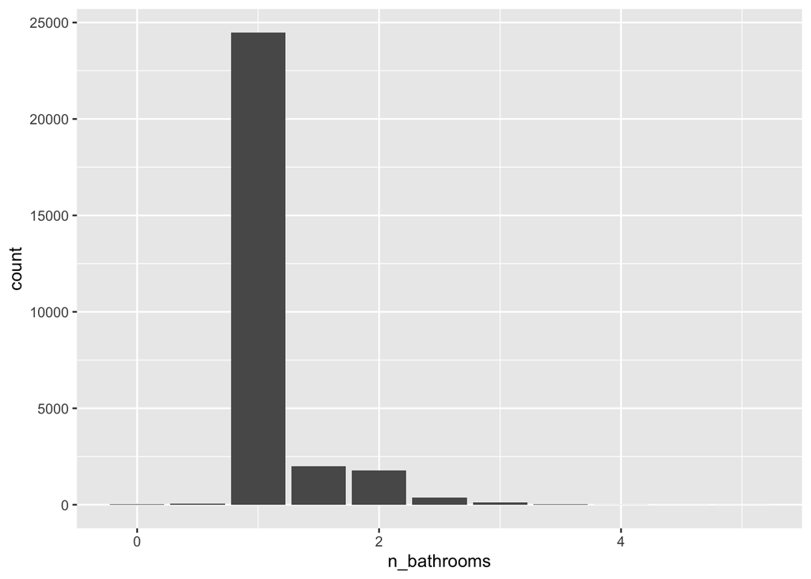

```r
ggplot(final_data, aes(x = n_bathrooms)) + geom_bar()
```

```r
summary(final_data$n_beds)
```

```
##    Min. 1st Qu.  Median    Mean 3rd Qu.    Max.    NA's
##   0.000   1.000   2.000   1.778   2.000   9.000      79
```

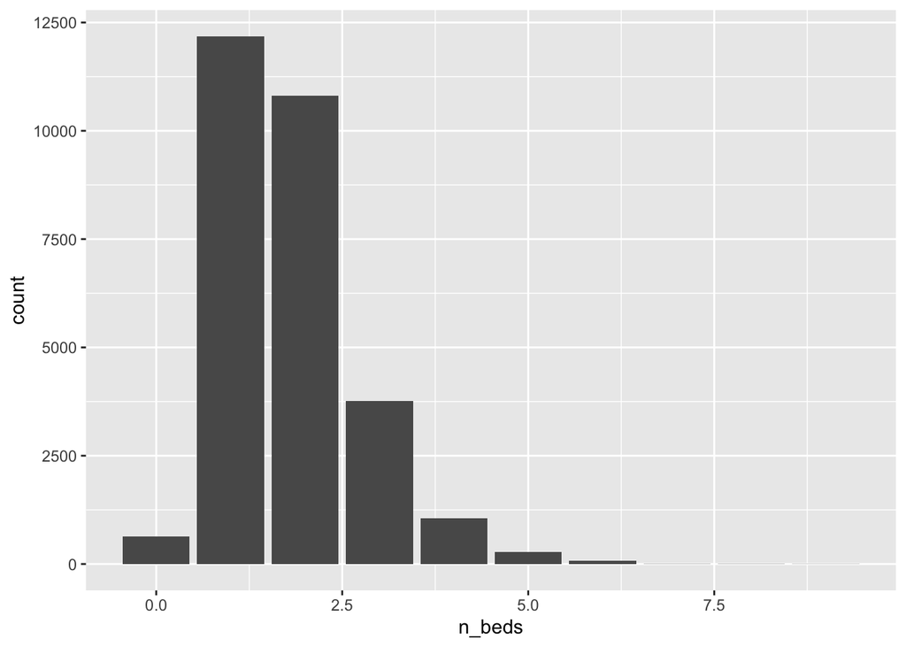

```r
ggplot(final_data, aes(x = n_beds)) + geom_bar()
```

```r
final_data <- final_data %>%
  mutate(n_bathrooms =  ifelse(is.na(n_bathrooms), median(n_bathrooms, na.rm = T), n_bathrooms), # assume 1 toilet
         n_beds = ifelse(is.na(n_beds), n_accommodates, n_beds))
```

Another variable, n_host_acceptance_rate, should be deleted, because more than 50% of its observations are NAs.

```r
final_data <- final_data %>%
  select(-n_host_acceptance_rate)
```

Other variables (reviews_per_month, days_since_first, days_since_last, n_review_scores_rating, n_review_scores_location) contain lots of NAs. However, I believe that they might be important for the analysis. For this reason, I impute them with their median values, but also flag that I imputed them.

```r
summary(final_data$n_reviews_per_month)
```

```
##    Min. 1st Qu.  Median    Mean 3rd Qu.    Max.    NA's
##   0.010   0.130   0.380   0.735   0.940  17.760    6135
```

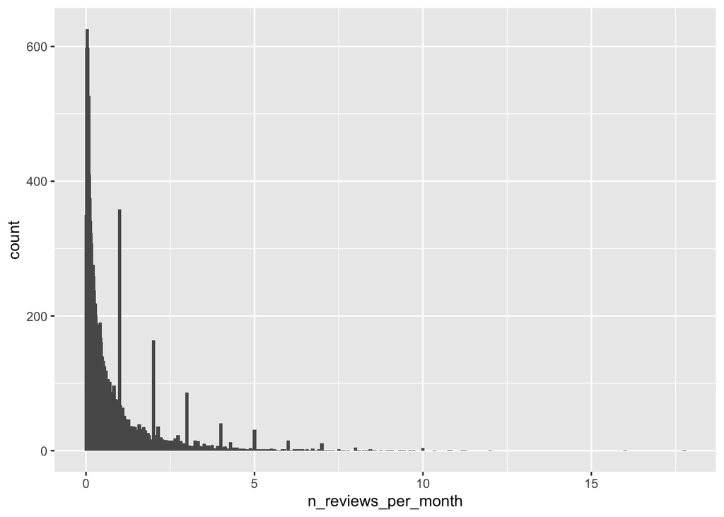

```r
ggplot(final_data, aes(x = n_reviews_per_month)) + geom_bar(width = 0.1)
```

```r
summary(final_data$n_days_since_first)
```

```
##    Min. 1st Qu.  Median    Mean 3rd Qu.    Max.    NA's
##       0     707    1168    1260    1856    4053    6135
```

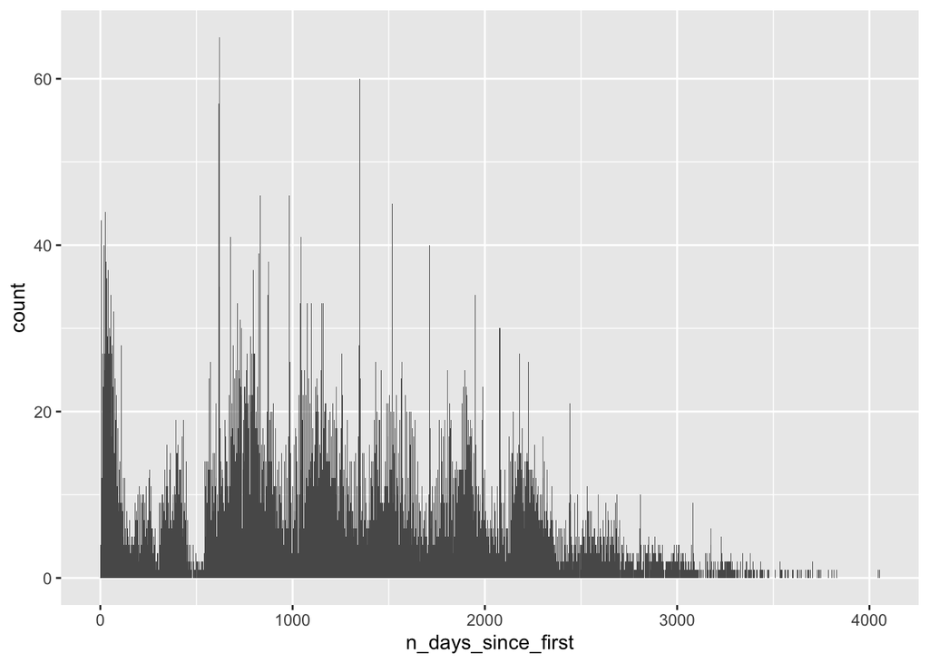

```r
ggplot(final_data, aes(x = n_days_since_first)) + geom_bar(width = 3)
```

```r
summary(final_data$n_days_since_last)
```

```
##    Min. 1st Qu.  Median    Mean 3rd Qu.    Max.    NA's
##     0.0   240.5   701.0   776.4  1095.0  3831.0    6135
```

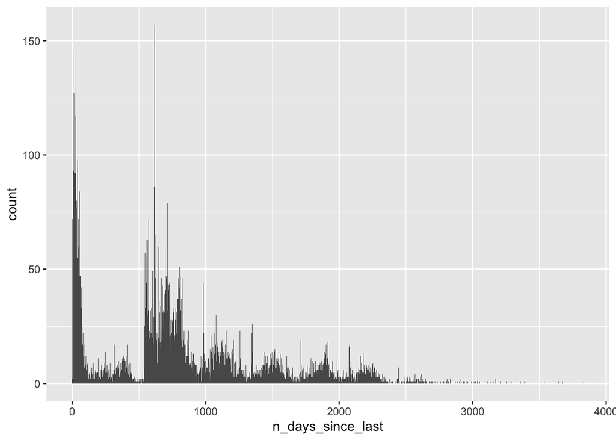

```r
ggplot(final_data, aes(x = n_days_since_last)) + geom_bar(width = 3)
```

```r
summary(final_data$n_review_scores_rating)
```

```
##    Min. 1st Qu.  Median    Mean 3rd Qu.    Max.    NA's
##   0.000   4.550   4.800   4.615   5.000   5.000    6135
```

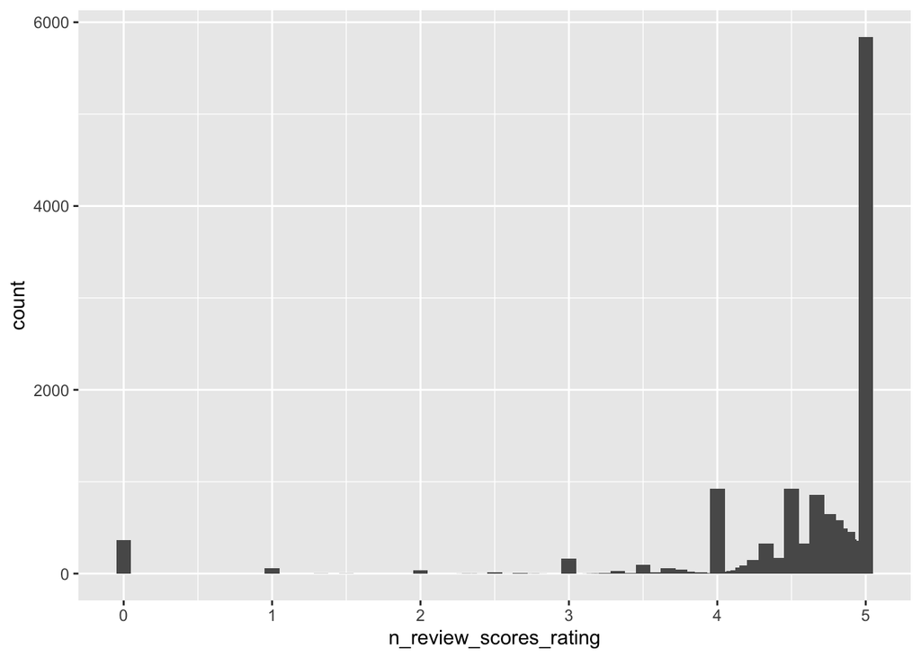

```r
ggplot(final_data, aes(x = n_review_scores_rating)) + geom_bar(width = 0.1)
```

```r
summary(final_data$n_review_scores_location)
```

```
##    Min. 1st Qu.  Median    Mean 3rd Qu.    Max.    NA's
##   0.000   4.750   4.920   4.814   5.000   5.000    6515
```

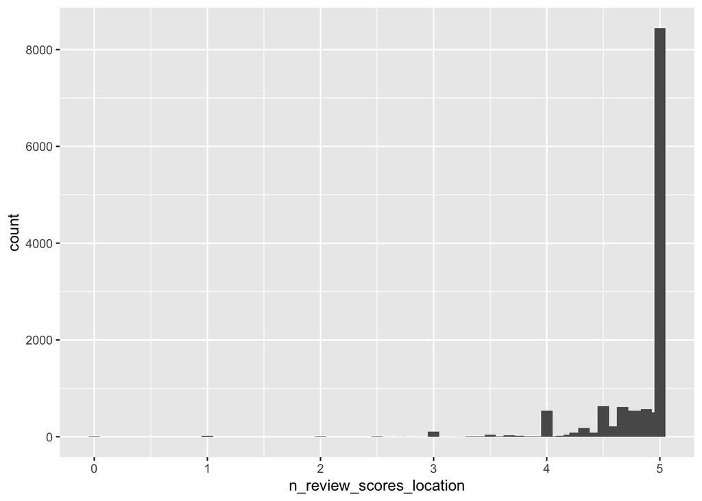

```r
ggplot(final_data, aes(x = n_review_scores_location)) + geom_bar(width = 0.1)
```

```r
final_data <- final_data %>%
  mutate(flag_reviews_per_month = factor(ifelse(is.na(n_reviews_per_month), 1, 0)),
         n_reviews_per_month =  ifelse(is.na(n_reviews_per_month), median(n_reviews_per_month, na.rm = T), n_reviews_per_month),
         flag_days_since_first = factor(ifelse(is.na(n_days_since_first), 1, 0)),
         n_days_since_first = ifelse(is.na(n_days_since_first), median(n_days_since_first, na.rm = T), n_days_since_first),
         flag_days_since_last = factor(ifelse(is.na(n_days_since_last), 1, 0)),
         n_days_since_last = ifelse(is.na(n_days_since_last), median(n_days_since_last, na.rm = T), n_days_since_last),
        flag_review_rating = factor(ifelse(is.na(n_review_scores_rating), 1, 0)),
         n_review_scores_rating =  ifelse(is.na(n_review_scores_rating), median(n_review_scores_rating, na.rm = T), n_review_scores_rating),
         flag_review_location = factor(ifelse(is.na(n_review_scores_location), 1, 0)),
         n_review_scores_location = ifelse(is.na(n_review_scores_location), median(n_review_scores_location, na.rm = T), n_review_scores_location))
```

Now, we see no more NAs in the data.

```r
to_filter <- sapply(final_data, function(x) sum(is.na(x)))
to_filter[to_filter > 0]
```

```
## named integer(0)
```

It can be useful to use factors instead of some quantitative variables, let's have a look.

```r
summary(final_data$n_bathrooms)
```

```
##    Min. 1st Qu.  Median    Mean 3rd Qu.    Max.
##   0.000   1.000   1.000   1.124   1.000   5.000
```

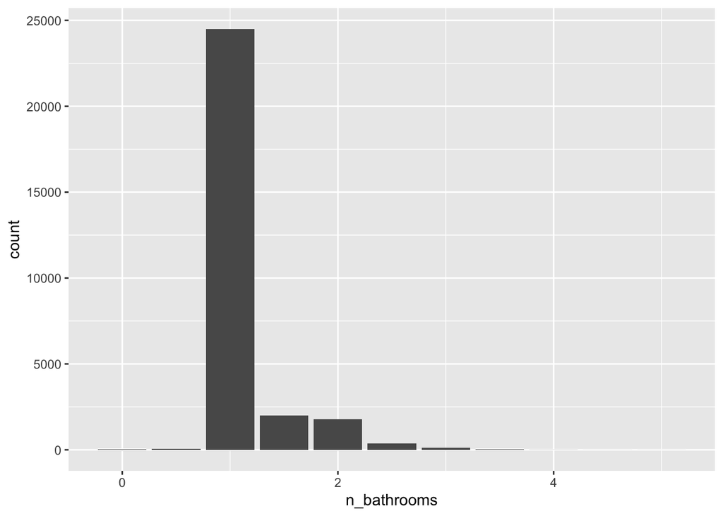

```r
ggplot(final_data, aes(x = n_bathrooms)) + geom_bar() # makes sense to make <=1 and >1
```

```r
summary(final_data$n_accommodates)
```

```
##    Min. 1st Qu.  Median    Mean 3rd Qu.    Max.
##   2.000   2.000   3.000   3.333   4.000   6.000
```

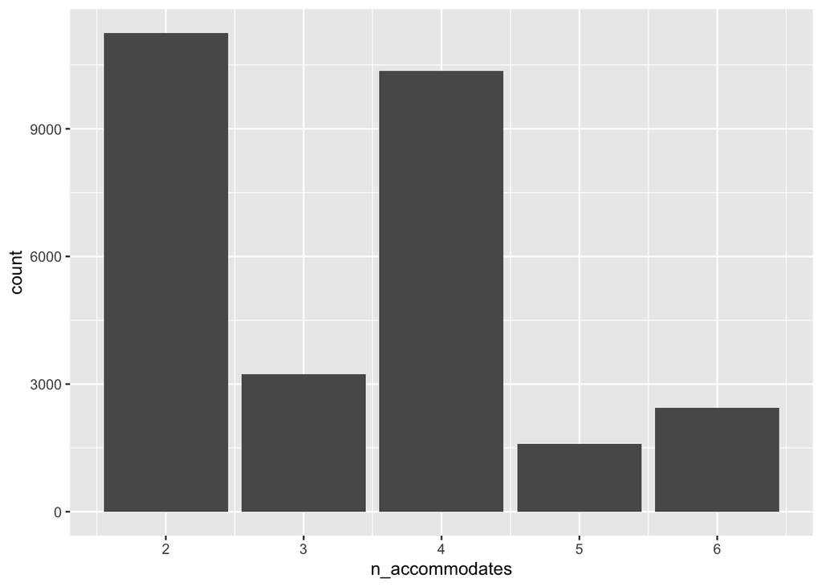

```r
ggplot(final_data, aes(x = n_accommodates)) + geom_bar() # I think factor is not necessary here
```

```r
summary(final_data$n_beds)
```

```
##    Min. 1st Qu.  Median    Mean 3rd Qu.    Max.
##   0.000   1.000   2.000   1.779   2.000   9.000
```

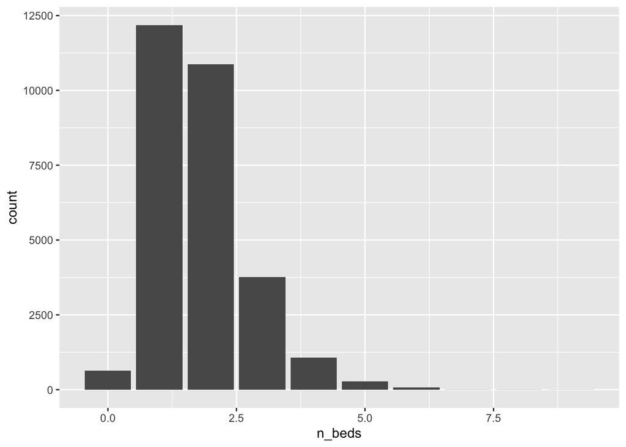

```r
ggplot(final_data, aes(x = n_beds)) + geom_bar() # makes sense to make <=1, 2, 3, >=4
```

```r
summary(final_data$n_minimum_nights)
```

```
##    Min. 1st Qu.  Median    Mean 3rd Qu.    Max.
##     1.0     2.0     5.0   132.1   365.0  1124.0
```

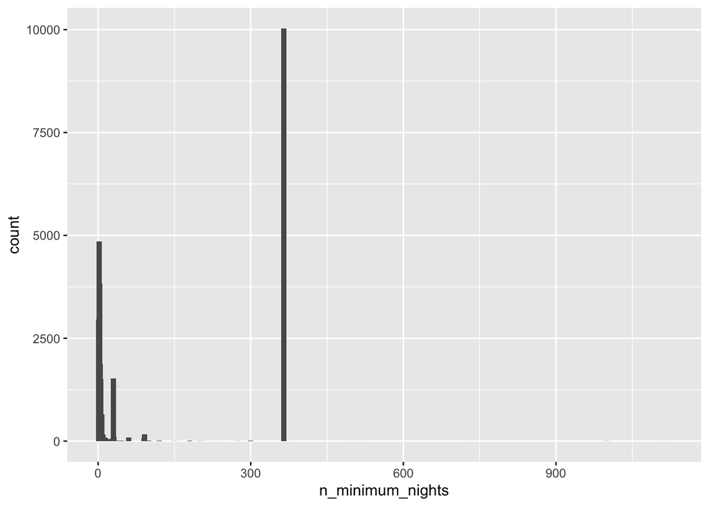

```r
ggplot(final_data, aes(x = n_minimum_nights)) + geom_bar(width = 10) # makes sense to make <=5, >=5 (5 is a median)
```

```r
summary(final_data$n_availability_60)
```

```
##    Min. 1st Qu.  Median    Mean 3rd Qu.    Max.
##    0.00    0.00    0.00   11.51   17.00   60.00
```

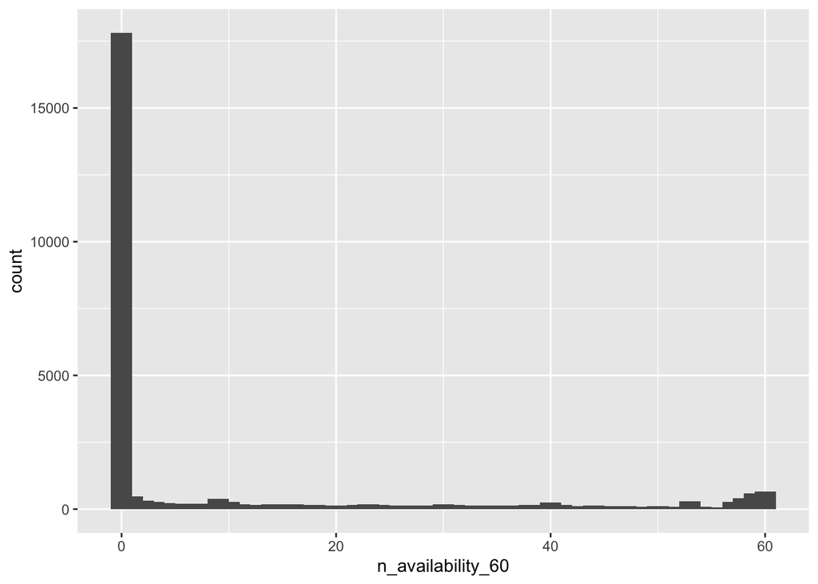

```r
ggplot(final_data, aes(x = n_availability_60)) + geom_bar(width = 2) # makes sense to make 0, >0
```

```r
final_data <- final_data %>%
  mutate(b_bathrooms = factor(ifelse(n_bathrooms <= 1, 1, 0)),
         f_beds = factor(ifelse(n_beds <= 1, 1, ifelse(n_beds <= 2, 2, ifelse(n_beds <= 3, 3, 4)))),
         b_minimum_nights = factor(ifelse(n_minimum_nights <= 5, 1, 0)),
         b_availability_60 = factor(ifelse(n_availability_60 == 0, 0, 1)))
```

Finally, let's also add some interesting features for the LASSO regression (like lns and squared lns for several quantitative variables).

```r
final_data <- final_data %>%
  mutate(ln_minimum_nights = ifelse(n_minimum_nights > 0, log(n_minimum_nights), 0),
         ln_days_since_first = ifelse(n_days_since_first > 0, log(n_days_since_first), 0),
         ln_days_since_first2 = ln_days_since_first^2,
         ln_days_since_last = ifelse(n_days_since_last > 0, log(n_days_since_last), 0),
         ln_days_since_last2 = ln_days_since_last^2,
         ln_review_rating = ifelse(n_review_scores_rating > 0, log(n_review_scores_rating), 0),
         ln_review_rating2 = ln_review_rating^2,
         ln_review_location = ifelse(n_review_scores_location > 0, log(n_review_scores_location), 0),
         ln_review_location2 = ln_review_location^2)
```

The description of the data is below:

```r
skimr::skim(final_data)
```

Data summary

| Name | final_data |
| --- | --- |
| Number of rows | 28878 |
| Number of columns | 42 |
| Key | NULL |
| _______________________ |  |
| Column type frequency: |  |
| factor | 20 |
| numeric | 22 |
| ________________________ |  |
| Group variables | None |

**Variable type: factor**

| skim_variable | n_missing | complete_rate | ordered | n_unique | top_counts |
| --- | --- | --- | --- | --- | --- |
| b_superhost | 0 | 1 | FALSE | 2 | 0: 24959, 1: 3919 |
| b_wifi | 0 | 1 | FALSE | 2 | 1: 27597, 0: 1281 |
| b_tv | 0 | 1 | FALSE | 2 | 1: 20689, 0: 8189 |
| b_coffee | 0 | 1 | FALSE | 2 | 0: 15147, 1: 13731 |
| b_netflix | 0 | 1 | FALSE | 2 | 0: 28689, 1: 189 |
| b_breakfast | 0 | 1 | FALSE | 2 | 0: 25900, 1: 2978 |
| b_freepark | 0 | 1 | FALSE | 2 | 0: 27897, 1: 981 |
| b_cleanprod | 0 | 1 | FALSE | 2 | 0: 26214, 1: 2664 |
| b_bedlinens | 0 | 1 | FALSE | 2 | 0: 16507, 1: 12371 |
| b_workspace | 0 | 1 | FALSE | 2 | 1: 18113, 0: 10765 |
| f_neighbourhood_clean | 0 | 1 | FALSE | 20 | But: 3475, Pop: 2837, Ent: 2151, Vau: 2040 |
| flag_reviews_per_month | 0 | 1 | FALSE | 2 | 0: 22743, 1: 6135 |
| flag_days_since_first | 0 | 1 | FALSE | 2 | 0: 22743, 1: 6135 |
| flag_days_since_last | 0 | 1 | FALSE | 2 | 0: 22743, 1: 6135 |
| flag_review_rating | 0 | 1 | FALSE | 2 | 0: 22743, 1: 6135 |
| flag_review_location | 0 | 1 | FALSE | 2 | 0: 22363, 1: 6515 |
| b_bathrooms | 0 | 1 | FALSE | 2 | 1: 24586, 0: 4292 |
| f_beds | 0 | 1 | FALSE | 4 | 1: 12822, 2: 10866, 3: 3762, 4: 1428 |
| b_minimum_nights | 0 | 1 | FALSE | 2 | 1: 15033, 0: 13845 |
| b_availability_60 | 0 | 1 | FALSE | 2 | 0: 17815, 1: 11063 |

**Variable type: numeric**

| skim_variable | n_missing | complete_rate | mean | sd | p0 | p25 | p50 | p75 | p100 | hist |
| --- | --- | --- | --- | --- | --- | --- | --- | --- | --- | --- |
| price | 0 | 1 | 128.35 | 183.19 | 8.00 | 70.00 | 98.00 | 141.00 | 11600.00 | ▇▁▁▁▁ |
| lnprice | 0 | 1 | 4.65 | 0.56 | 2.08 | 4.25 | 4.58 | 4.95 | 9.36 | ▁▇▂▁▁ |
| n_accommodates | 0 | 1 | 3.33 | 1.27 | 2.00 | 2.00 | 3.00 | 4.00 | 6.00 | ▇▂▇▁▂ |
| n_bathrooms | 0 | 1 | 1.12 | 0.34 | 0.00 | 1.00 | 1.00 | 1.00 | 5.00 | ▇▁▁▁▁ |
| n_beds | 0 | 1 | 1.78 | 0.94 | 0.00 | 1.00 | 2.00 | 2.00 | 9.00 | ▇▇▁▁▁ |
| n_minimum_nights | 0 | 1 | 132.06 | 171.26 | 1.00 | 2.00 | 5.00 | 365.00 | 1124.00 | ▇▅▁▁▁ |
| n_availability_60 | 0 | 1 | 11.51 | 19.16 | 0.00 | 0.00 | 0.00 | 17.00 | 60.00 | ▇▁▁▁▁ |
| n_number_of_reviews | 0 | 1 | 19.68 | 38.40 | 0.00 | 1.00 | 6.00 | 21.00 | 749.00 | ▇▁▁▁▁ |
| n_review_scores_rating | 0 | 1 | 4.65 | 0.64 | 0.00 | 4.64 | 4.80 | 4.92 | 5.00 | ▁▁▁▁▇ |
| n_reviews_per_month | 0 | 1 | 0.66 | 0.90 | 0.01 | 0.19 | 0.38 | 0.73 | 17.76 | ▇▁▁▁▁ |
| n_review_scores_location | 0 | 1 | 4.84 | 0.28 | 0.00 | 4.81 | 4.92 | 5.00 | 5.00 | ▁▁▁▁▇ |
| n_days_since_first | 0 | 1 | 1240.42 | 682.93 | 0.00 | 802.25 | 1168.00 | 1616.00 | 4053.00 | ▅▇▃▁▁ |
| n_days_since_last | 0 | 1 | 760.40 | 554.17 | 0.00 | 555.25 | 701.00 | 879.00 | 3831.00 | ▇▃▁▁▁ |
| ln_minimum_nights | 0 | 1 | 2.87 | 2.36 | 0.00 | 0.69 | 1.61 | 5.90 | 7.02 | ▇▂▁▁▆ |
| ln_days_since_first | 0 | 1 | 6.83 | 1.02 | 0.00 | 6.69 | 7.06 | 7.39 | 8.31 | ▁▁▁▂▇ |
| ln_days_since_first2 | 0 | 1 | 47.75 | 11.62 | 0.00 | 44.72 | 49.89 | 54.58 | 69.01 | ▁▁▁▇▃ |
| ln_days_since_last | 0 | 1 | 6.08 | 1.45 | 0.00 | 6.32 | 6.55 | 6.78 | 8.25 | ▁▁▂▇▆ |
| ln_days_since_last2 | 0 | 1 | 39.08 | 14.49 | 0.00 | 39.94 | 42.94 | 45.95 | 68.08 | ▂▁▁▇▁ |
| ln_review_rating | 0 | 1 | 1.53 | 0.20 | 0.00 | 1.53 | 1.57 | 1.59 | 1.61 | ▁▁▁▁▇ |
| ln_review_rating2 | 0 | 1 | 2.37 | 0.36 | 0.00 | 2.36 | 2.46 | 2.54 | 2.59 | ▁▁▁▁▇ |
| ln_review_location | 0 | 1 | 1.57 | 0.08 | 0.00 | 1.57 | 1.59 | 1.61 | 1.61 | ▁▁▁▁▇ |
| ln_review_location2 | 0 | 1 | 2.48 | 0.19 | 0.00 | 2.47 | 2.54 | 2.59 | 2.59 | ▁▁▁▁▇ |

```r
describe(final_data)
```

[output not shown]

[output cut: 312 more lines]

[output not shown]

## Building Models

First, let's create training and holdout sets. Training set contains 20217 observations (70%), holdout - 8661 (30%).

```r
train_indices <- as.integer(createDataPartition(final_data$lnprice, p = 0.7, list = FALSE))
data_train <- final_data[train_indices, ]
data_holdout <- final_data[-train_indices, ]

dim(data_train)
```

```
## [1] 20217    42
```

```r
dim(data_holdout)
```

```
## [1] 8661   42
```

Now, I can start building several models.

- Model 1: lnprice ~ n_accommodates + f_beds + n_bathrooms + b_superhost + n_minimum_nights + n_availability_60 + f_neighbourhood_clean - only $basic\ variables$
- Model 2: lnprice ~ $basic\ variables$ + n_review_scores_rating + flag_review_rating + n_review_scores_location + flag_review_location + n_reviews_per_month + flag_reviews_per_month + n_days_since_first + flag_days_since_first + n_days_since_last + flag_days_since_last - $basic\ variables$ + largely $imputed\ variables$
- Model 3: lnprice ~ $basic\ variables$ + $imputed\ variables$ + b_wifi + b_tv + b_coffee + b_netflix + b_breakfast + b_freepark + b_cleanprod + b_bedlinens + b_workspace - $basic\ variables$ + $imputed\ variables$ + $selected\ amenities$
- Model 4 (for LASSO): lnprice ~ $basic\ variables$ + $imputed\ variables$ + $selected\ amenities$ + $squares$ + $interactions$

```r
# basic variables, with neighbourhood
basic_vars <- c("n_accommodates", "f_beds", "n_bathrooms", "b_superhost", "n_minimum_nights", "n_availability_60",
  "f_neighbourhood_clean")

# largely imputed variables
reviews <- c("n_review_scores_rating", "flag_review_rating" ,"n_review_scores_location", "flag_review_location",
             "n_reviews_per_month", "flag_reviews_per_month" ,"n_days_since_first", "flag_days_since_first",
             "n_days_since_last", "flag_days_since_last" )

# dummy variables
amenities <-  grep("^b_.*", names(final_data), value = TRUE)
amenities <- amenities[-1] # because superhost is already used
amenities <- amenities[1:9] # dummies related to amenities

#interactions and squares for the LASSO
# squares
squares <- grep("2$", names(final_data), value = TRUE)

# in general
X1  <- c("n_accommodates*n_bathrooms",  "n_accommodates*n_availability_60",  "n_review_scores_rating*b_superhost",
         "b_netflix*b_superhost", "b_freepark*n_accommodates", "b_bedlinens*n_accommodates")
# with neighbourhoods
X2  <- c("f_beds*f_neighbourhood_clean", "n_bathrooms*f_neighbourhood_clean",
         "n_accommodates*f_neighbourhood_clean", "n_minimum_nights*f_neighbourhood_clean",
         "b_superhost*f_neighbourhood_clean")


predictors_1 <- c(basic_vars)
predictors_2 <- c(basic_vars, reviews)
predictors_3 <- c(basic_vars, reviews, amenities)
predictors_E <- c(basic_vars, reviews, amenities, squares, X1, X2)
```

Now, I am building random forests for each of the models with a set tuning + autotuning for the 3 model. There results can be seen below.

```r
######### random forest
# do 5-fold CV
train_control <- trainControl(method = "cv",
                              number = 5,
                              verboseIter = FALSE)

# set tuning for all models
tune_grid <- expand.grid(
  .mtry = c(8, 10, 12),
  .splitrule = "variance",
  .min.node.size = c(5, 10, 15)
)

# model 1
set.seed(1234)
system.time({
  rf_model_1 <- train(
    formula(paste0("lnprice ~", paste0(predictors_1, collapse = " + "))),
    data = data_train,
    method = "ranger",
    trControl = train_control,
    tuneGrid = tune_grid,
    importance = "impurity"
  )
})
```

```
##    user  system elapsed
## 897.854   9.070 152.038
```

```r
# model 2
set.seed(1234)
system.time({
  rf_model_2 <- train(
    formula(paste0("lnprice ~", paste0(predictors_2, collapse = " + "))),
    data = data_train,
    method = "ranger",
    trControl = train_control,
    tuneGrid = tune_grid,
    importance = "impurity"
  )
})
```

```
##     user   system  elapsed
## 1344.066   15.945  232.989
```

```r
# model 3
set.seed(1234)
system.time({
  rf_model_3 <- train(
    formula(paste0("lnprice ~", paste0(predictors_3, collapse = " + "))),
    data = data_train,
    method = "ranger",
    trControl = train_control,
    tuneGrid = tune_grid,
    importance = "impurity"
  )
})
```

```
##     user   system  elapsed
## 1422.920   14.833  235.887
```

```r
# auto tuning for the model 3
set.seed(1234)
system.time({
   rf_model_3auto <- train(
     formula(paste0("lnprice ~", paste0(predictors_3, collapse = " + "))),
     data = data_train,
     method = "ranger",
     trControl = train_control,
     importance = "impurity"
   )
 })
```

```
##     user   system  elapsed
## 2516.192    6.809  339.818
```

```r
results <- resamples(
  list(
    model_1  = rf_model_1,
    model_2  = rf_model_2,
    model_3  = rf_model_3,
    model_3auto = rf_model_3auto
  )
)
summary(results)
```

```
##
## Call:
## summary.resamples(object = results)
##
## Models: model_1, model_2, model_3, model_3auto
## Number of resamples: 5
##
## MAE
##                  Min.   1st Qu.    Median      Mean   3rd Qu.      Max. NA's
## model_1     0.2948036 0.2964905 0.2993556 0.2987229 0.3001923 0.3027727    0
## model_2     0.2877442 0.2884375 0.2916510 0.2911968 0.2938745 0.2942768    0
## model_3     0.2840654 0.2865406 0.2890323 0.2881566 0.2898770 0.2912674    0
## model_3auto 0.2877289 0.2910630 0.2918504 0.2919939 0.2936962 0.2956311    0
##
## RMSE
##                  Min.   1st Qu.    Median      Mean   3rd Qu.      Max. NA's
## model_1     0.4003122 0.4019474 0.4051659 0.4105716 0.4177552 0.4276773    0
## model_2     0.3904159 0.3936004 0.3985875 0.4018369 0.4098070 0.4167738    0
## model_3     0.3859777 0.3911384 0.3952914 0.3979422 0.4063073 0.4109959    0
## model_3auto 0.3896013 0.3936448 0.3996272 0.4018833 0.4110984 0.4154451    0
##
## Rsquared
##                  Min.   1st Qu.    Median      Mean   3rd Qu.      Max. NA's
## model_1     0.4466276 0.4515667 0.4715307 0.4658925 0.4719563 0.4877810    0
## model_2     0.4679999 0.4809807 0.4897995 0.4897579 0.4940891 0.5159204    0
## model_3     0.4781646 0.4971192 0.4998935 0.5010623 0.5009513 0.5291831    0
## model_3auto 0.4639187 0.4824927 0.4858444 0.4881434 0.4932803 0.5151810    0
```

## Analysing Models Performance

It looks like model 3 has the best performance (the lowest RMSE), and hand-tuned model 3 works even better than autotuned. Therefore, I will focus on the hand-tuned model 3.

```r
# Turning parameter choice 2
result_2 <- matrix(c(mean(results$values$`model_1~RMSE`),
                     mean(results$values$`model_2~RMSE`),
                     mean(results$values$`model_3~RMSE`),
                     mean(results$values$`model_3auto~RMSE`)
),
nrow=4, ncol=1,
dimnames = list(c("Model 1", "Model 2", "Model 3", "Model 3 auto"),
                c(results$metrics[2]))
)


kable(x = result_2, format = "html", digits = 3)
```

|  | RMSE |
| --- | --- |
| Model 1 | 0.411 |
| Model 2 | 0.402 |
| Model 3 | 0.398 |
| Model 3 auto | 0.402 |

The following table helps to understand that the lowest RMSE is associated with 5 observations in the terminal nodes and 8 variables to consider at each split. However, it also should be noted that the differences in RMSE are very small - 0.0014 log price (1/280 of the mean RMSE values). It means that the random forest tends to be robust.

```r
rf_tuning_model3 <- rf_model_3$results %>%
  dplyr::select(mtry, min.node.size, RMSE) %>%
  dplyr::rename(nodes = min.node.size) %>%
  spread(key = mtry, value = RMSE)
rf_tuning_model3
```

| nodes | 8 | 10 | 12 |
| --- | --- | --- | --- |
| 5 | 0.3979422 | 0.3986314 | 0.3992977 |
| 10 | 0.3981216 | 0.3984816 | 0.3989030 |
| 15 | 0.3984570 | 0.3986563 | 0.3988190 |

```r
result_1 <- matrix(c(
  rf_model_1$finalModel$mtry,
  rf_model_2$finalModel$mtry,
  rf_model_3$finalModel$mtry,
  rf_model_3auto$finalModel$mtry,
  rf_model_1$finalModel$min.node.size,
  rf_model_2$finalModel$min.node.size,
  rf_model_3$finalModel$min.node.size,
  rf_model_3auto$finalModel$min.node.size

),
nrow=4, ncol=2,
dimnames = list(c("Model 1", "Model 2","Model 3", "Model 3 auto"),
                c("Min vars","Min nodes"))
)

kable(x = result_1, format = "html", digits = 3)
```

|  | Min vars | Min nodes |
| --- | --- | --- |
| Model 1 | 8 | 15 |
| Model 2 | 8 | 15 |
| Model 3 | 8 | 5 |
| Model 3 auto | 24 | 5 |

## Model Diagnostics

Let's first build the variable importance plot. At cutoff point = 0.15, 11 variables are important for predicting ln price, and the largest three are the number of bathrooms, the number of accomodates, and the number of days when an appartment was available during the last 60 days.

```r
group.importance <- function(rf.obj, groups) {
  var.imp <- as.matrix(sapply(groups, function(g) {
    sum(ranger::importance(rf.obj)[g], na.rm = TRUE)
  }))
  colnames(var.imp) <- "MeanDecreaseGini"
  return(var.imp)
}


rf_model_3_var_imp <- ranger::importance(rf_model_3$finalModel)/1000
rf_model_3_var_imp_df <-
  data.frame(varname = names(rf_model_3_var_imp),imp = rf_model_3_var_imp) %>%
  mutate(varname = gsub("f_neighbourhood_cleansed", "Borough:", varname) ) %>%
  mutate(varname = gsub("f_room_type", "Room type:", varname) ) %>%
  arrange(desc(imp)) %>%
  mutate(imp_percentage = imp/sum(imp))
```

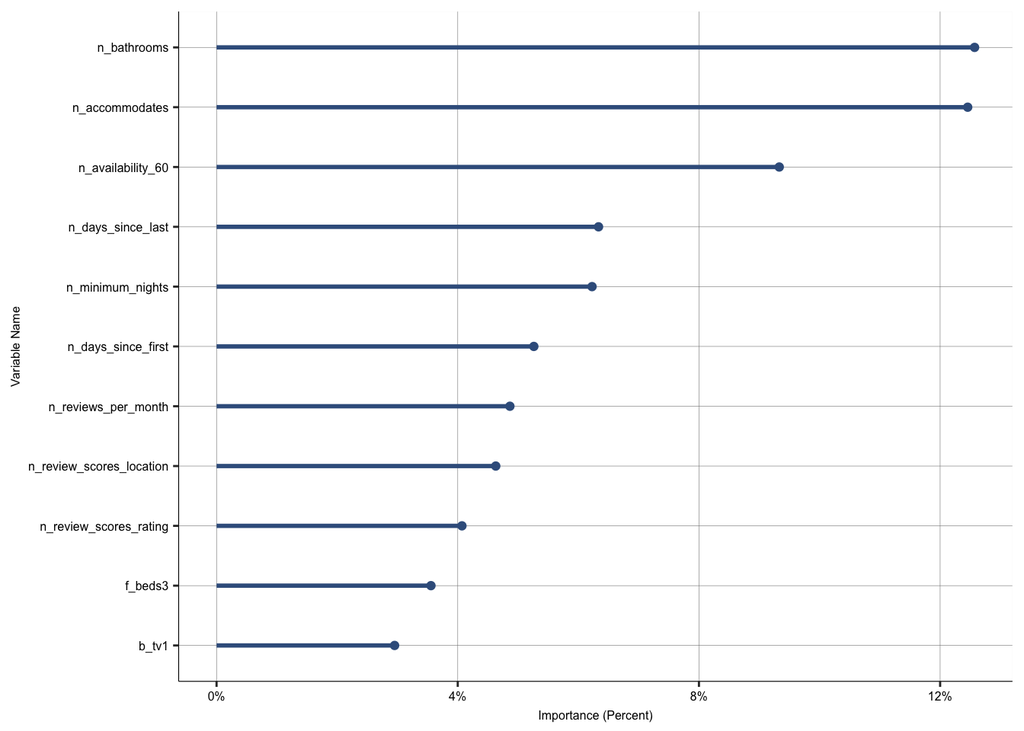

```r
cutoff = 0.15
ggplot(rf_model_3_var_imp_df[rf_model_3_var_imp_df$imp>cutoff,],
                                  aes(x=reorder(varname, imp), y=imp_percentage)) +
  geom_point(color=color[1], size=1.5) +
  geom_segment(aes(x=varname,xend=varname,y=0,yend=imp_percentage), color=color[1], size=1) +
  ylab("Importance (Percent)") +
  xlab("Variable Name") +
  coord_flip() +
  scale_y_continuous(labels = scales::percent_format(accuracy = 1)) +
  theme_bg() +
  theme(axis.text.x = element_text(size=6), axis.text.y = element_text(size=6),
        axis.title.x = element_text(size=6), axis.title.y = element_text(size=6))
```

It is also useful to combine different factors and too look at their joint importance (together with the three largest variables from the previous plot and two binaries: superhost and tv). The situation has changed: now, neigbourhood is the most important variable, then go number of bathrooms and the number of accomodates, then - availability60, factor of beds and the availability of TV.

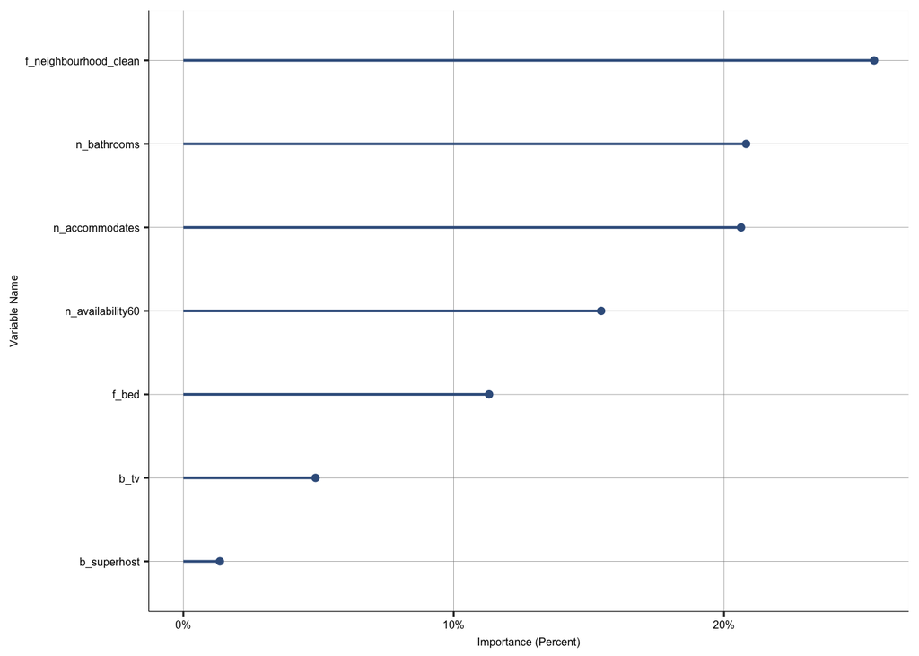

```r
varnames <- rf_model_3$finalModel$xNames

f_neighbourhood_clean_varnames <- grep("f_neighbourhood_clean",varnames, value = TRUE)
f_bed_clean_varnames <- grep("f_bed",varnames, value = TRUE)

groups <- list(f_neighbourhood_clean = f_neighbourhood_clean_varnames,
               f_bed = f_bed_clean_varnames,
               b_superhost = "b_superhost1",
               b_tv = "b_tv1",
               n_bathrooms = "n_bathrooms",
               n_accommodates = "n_accommodates",
               n_availability60 = "n_availability_60")

rf_model_3_var_imp_grouped <- group.importance(rf_model_3$finalModel, groups)
rf_model_3_var_imp_grouped_df <- data.frame(varname = rownames(rf_model_3_var_imp_grouped),
                                            imp = rf_model_3_var_imp_grouped[,1])  %>%
  mutate(imp_percentage = imp/sum(imp))


ggplot(rf_model_3_var_imp_grouped_df, aes(x=reorder(varname, imp), y=imp_percentage)) +
  geom_point(color=color[1], size=1.5) +
  geom_segment(aes(x=varname,xend=varname,y=0,yend=imp_percentage), color=color[1], size=0.7) +
  ylab("Importance (Percent)") +   xlab("Variable Name") +
  coord_flip() +
  # expand=c(0,0),
  scale_y_continuous(labels = scales::percent_format(accuracy = 1)) +
  theme_bg() +
  theme(axis.text.x = element_text(size=6), axis.text.y = element_text(size=6),
        axis.title.x = element_text(size=6), axis.title.y = element_text(size=6))
```

Now we can also look at some partial dependence plots for the factor of neighborhoods, number of accomodates, number of bathrooms, factor of beds, and availability of a TV.

```r
pdp_n_neigh <- pdp::partial(rf_model_3, pred.var = "f_neighbourhood_clean", pred.grid = distinct_(data_holdout, "f_neighbourhood_clean"), train = data_train)
```

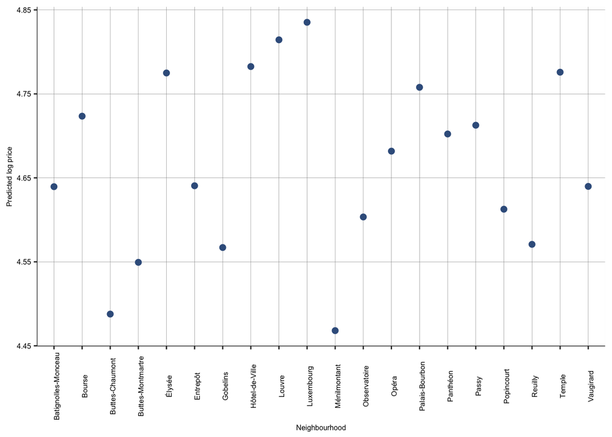

```r
pdp_n_neigh_plot <- pdp_n_neigh %>%
  autoplot( ) +
  geom_point(color=color[1], size=2) +
  ylab("Predicted log price") +
  xlab("Neighbourhood") +
  theme_bg() +
  theme(axis.text.x = element_text(angle = 90))
pdp_n_neigh_plot
```

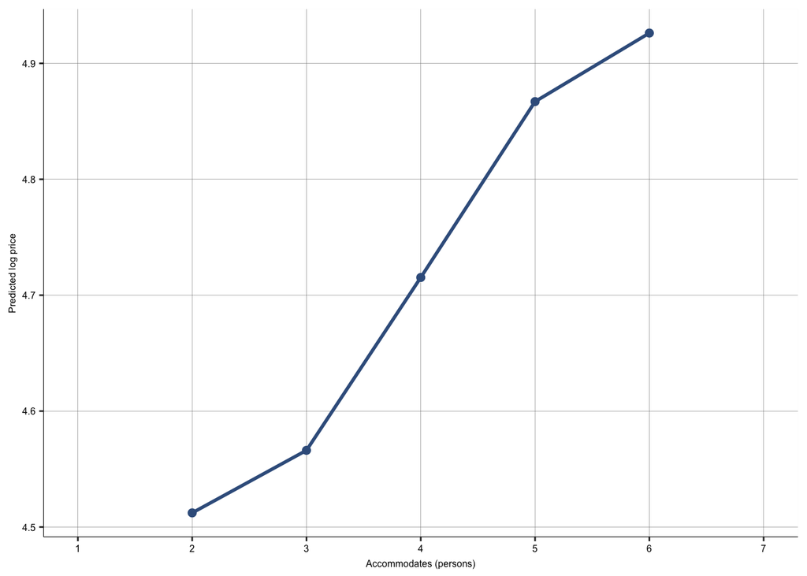

```r
pdp_n_acc <- pdp::partial(rf_model_3, pred.var = "n_accommodates", pred.grid = distinct_(data_holdout, "n_accommodates"), train = data_train)
pdp_n_acc_plot <- pdp_n_acc %>%
  autoplot( ) +
  geom_point(color=color[1], size=2) +
  geom_line(color=color[1], size=1) +
  ylab("Predicted log price") +
  xlab("Accommodates (persons)") +
  scale_x_continuous(limit=c(1,7), breaks=seq(1,7,1))+
  theme_bg()
pdp_n_acc_plot
```

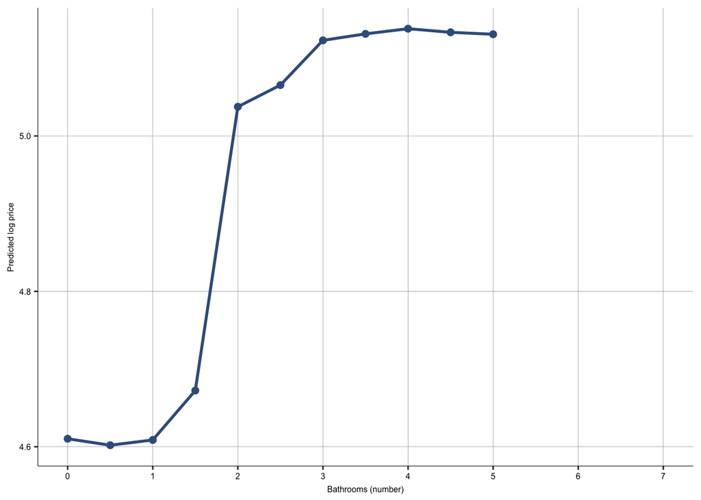

```r
pdp_n_bath <- pdp::partial(rf_model_3, pred.var = "n_bathrooms", pred.grid = distinct_(data_holdout, "n_bathrooms"), train = data_train)
pdp_n_bath_plot <- pdp_n_bath %>%
  autoplot( ) +
  geom_point(color=color[1], size=2) +
  geom_line(color=color[1], size=1) +
  ylab("Predicted log price") +
  xlab("Bathrooms (number)") +
  scale_x_continuous(limit=c(0,7), breaks=seq(0,7,1))+
  theme_bg()
pdp_n_bath_plot
```

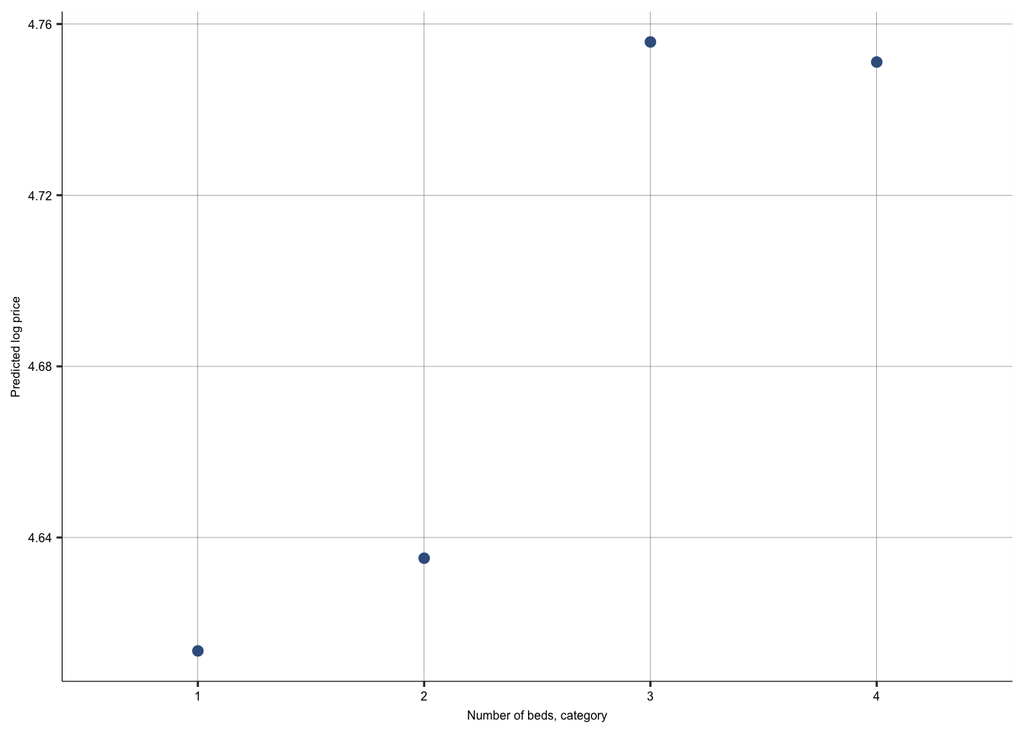

```r
pdp_f_bed <- pdp::partial(rf_model_3, pred.var = "f_beds", pred.grid = distinct_(data_holdout, "f_beds"), train = data_train)
pdp_f_bed_plot <- pdp_f_bed %>%
  autoplot( ) +
  geom_point(color=color[1], size=2) +
  ylab("Predicted log price") +
  xlab("Number of beds, category") +
  theme_bg()
pdp_f_bed_plot
```

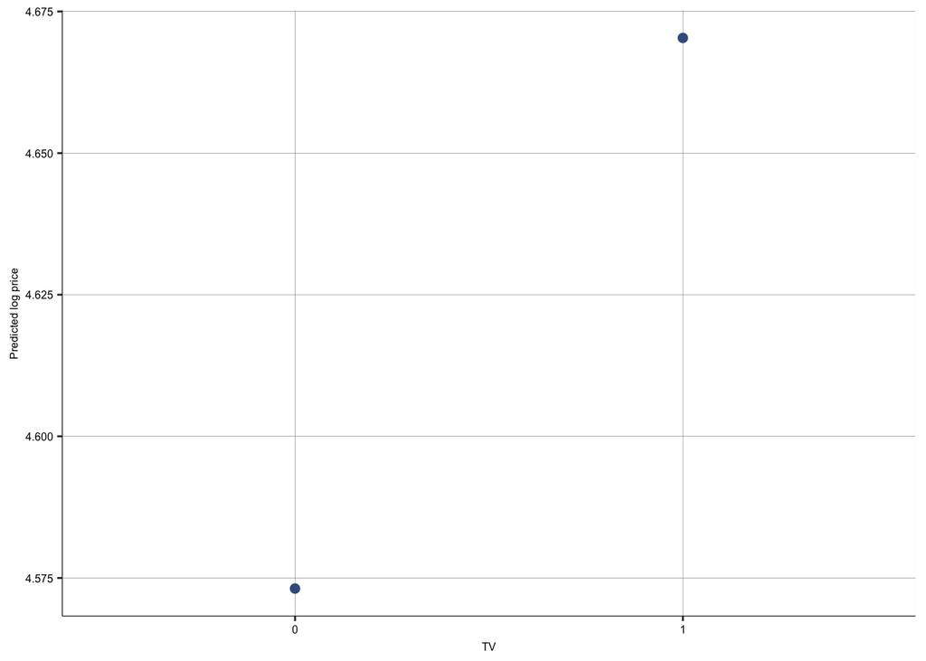

```r
pdp_b_tv <- pdp::partial(rf_model_3, pred.var = "b_tv", pred.grid = distinct_(data_holdout, "b_tv"), train = data_train)
pdp_b_tv_plot <- pdp_b_tv %>%
  autoplot( ) +
  geom_point(color=color[1], size=2) +
  ylab("Predicted log price") +
  xlab("TV") +
  theme_bg()
pdp_b_tv_plot
```

Finally, we can also look at the scatter plot of model's prediction and the actual ln prices. I would say that the results are comparatively well, even though there are some quite noticeable extreme values.

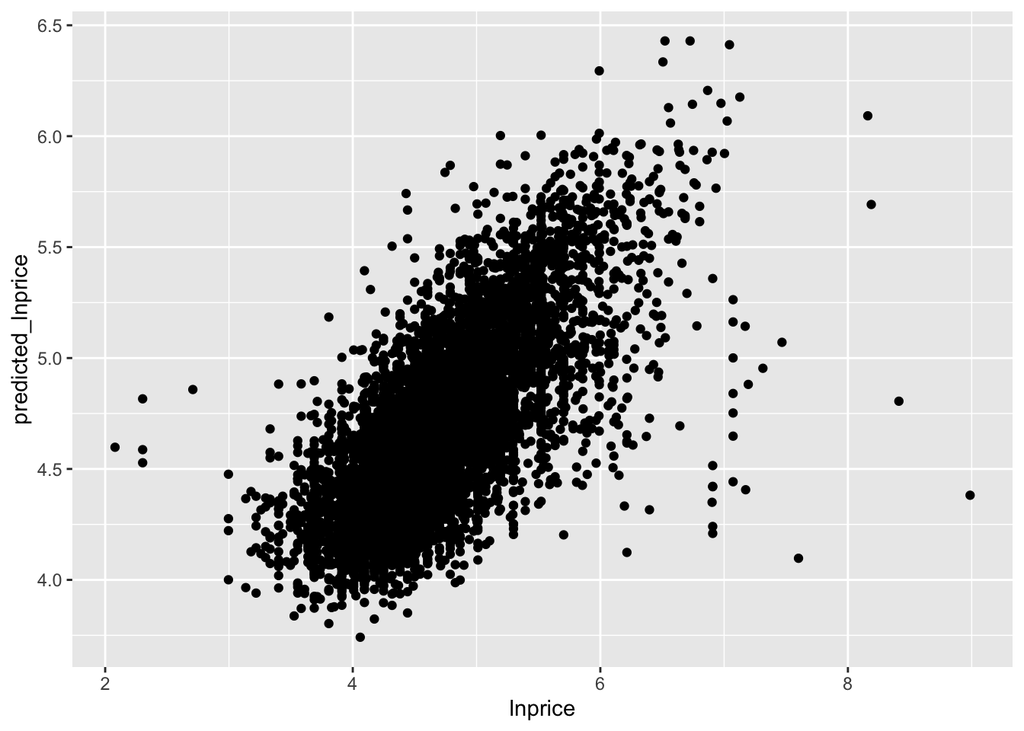

```r
data_holdout_w_prediction <- data_holdout %>%
  mutate(predicted_lnprice = predict(rf_model_3, newdata = data_holdout))
data_holdout_w_prediction %>%
  select(lnprice, predicted_lnprice) %>%
  ggplot(aes(lnprice, predicted_lnprice)) + geom_point()
```

## Comparing Models Performance

Now, I can also build some other models and compare their performances with the random forests. I am building OLS with all predictors used for the model 3, LASSO, a regression tree through CART, GBM with small tuning (I had to exclude broad tuning due to my impatience and time constraints). The results can be seen below.

```r
# OLS with dummies for area
# using model B

set.seed(1234)
system.time({
ols_model <- train(
  formula(paste0("lnprice ~", paste0(predictors_3, collapse = " + "))),
  data = data_train,
  method = "lm",
  trControl = train_control
)
})
```

```
##    user  system elapsed
##   1.387   0.007   1.397
```

```r
ols_model_coeffs <-  ols_model$finalModel$coefficients
ols_model_coeffs_df <- data.frame(
  "variable" = names(ols_model_coeffs),
  "ols_coefficient" = ols_model_coeffs
) %>%
  mutate(variable = gsub("`","",variable))

# * LASSO
# using extended model w interactions

set.seed(1234)
system.time({
lasso_model <- train(
  formula(paste0("lnprice ~", paste0(predictors_E, collapse = " + "))),
  data = data_train,
  method = "glmnet",
  preProcess = c("center", "scale"),
  tuneGrid =  expand.grid("alpha" = 1, "lambda" = seq(0.01, 0.25, by = 0.01)),
  trControl = train_control
)
})
```

```
##    user  system elapsed
##  14.192   0.420  14.656
```

```r
lasso_coeffs <- coef(
    lasso_model$finalModel,
    lasso_model$bestTune$lambda) %>%
  as.matrix() %>%
  as.data.frame() %>%
  rownames_to_column(var = "variable") %>%
  rename(lasso_coefficient = `1`)  # the column has a name "1", to be renamed

lasso_coeffs_non_null <- lasso_coeffs[!lasso_coeffs$lasso_coefficient == 0,]

regression_coeffs <- merge(ols_model_coeffs_df, lasso_coeffs_non_null, by = "variable", all=TRUE)

# CART
set.seed(1234)
system.time({
cart_model <- train(
  formula(paste0("lnprice ~", paste0(predictors_3, collapse = " + "))),
  data = data_train,
  method = "rpart",
  tuneLength = 10,
  trControl = train_control
)
})
```

```
##    user  system elapsed
##   5.027   0.115   5.250
```

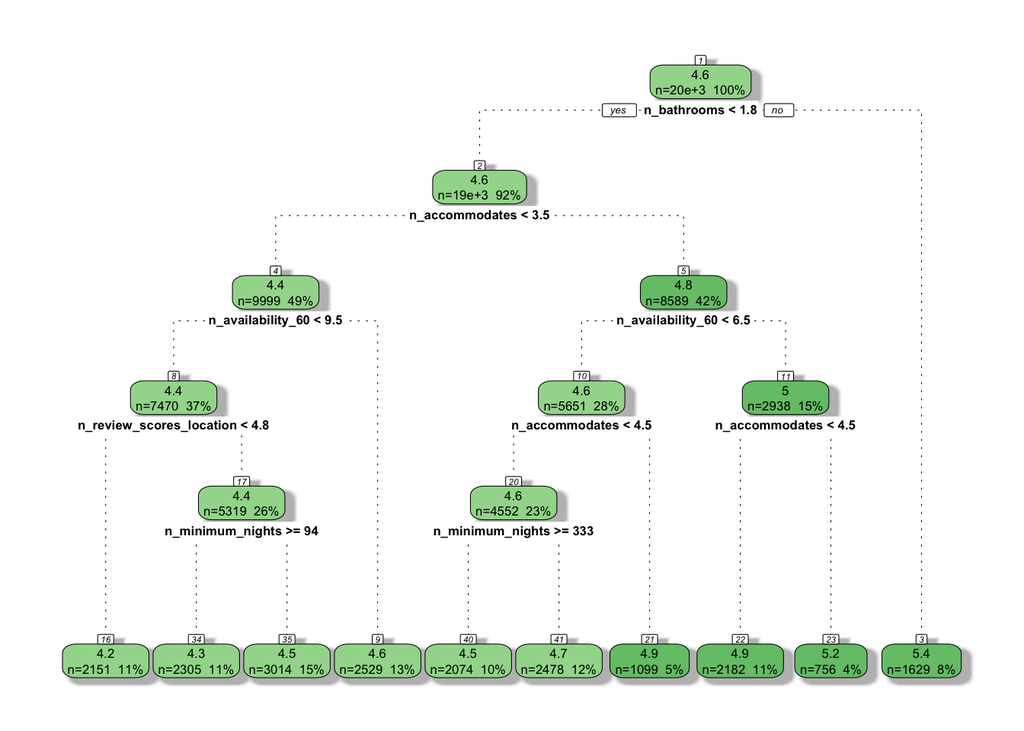

```r
fancyRpartPlot(cart_model$finalModel, sub = "")
```

```r
# GBM  small
gbm_grid <-  expand.grid(interaction.depth = c(1, 5, 10), # complexity of the tree
                         n.trees = (4:10)*50, # number of iterations, i.e. trees
                         shrinkage = 0.1, # learning rate: how quickly the algorithm adapts
                         n.minobsinnode = 20 # the minimum number of training set samples in a node to commence splitting
)


set.seed(1234)
system.time({
  gbm_model <- train(formula(paste0("lnprice ~", paste0(predictors_3, collapse = " + "))),
                     data = data_train,
                     method = "gbm",
                     trControl = train_control,
                     verbose = FALSE,
                     tuneGrid = gbm_grid)
})
```

```
##    user  system elapsed
## 273.936   0.581 274.746
```

```r
final_models <-
  list("OLS" = ols_model,
  "LASSO (model w/ interactions)" = lasso_model,
  "CART" = cart_model,
  "Random forest 1" = rf_model_1,
  "Random forest 2" = rf_model_2,
  "Random forest 3" = rf_model_3,
  "GBM (basic tuning)"  = gbm_model)

results <- resamples(final_models) %>% summary()
results
```

```
##
## Call:
## summary.resamples(object = .)
##
## Models: OLS, LASSO (model w/ interactions), CART, Random forest 1, Random forest 2, Random forest 3, GBM (basic tuning)
## Number of resamples: 5
##
## MAE
##                                    Min.   1st Qu.    Median      Mean   3rd Qu.
## OLS                           0.2870507 0.2879039 0.2920001 0.2908020 0.2935166
## LASSO (model w/ interactions) 0.2891766 0.2901219 0.2921192 0.2923877 0.2946913
## CART                          0.3312247 0.3316287 0.3350996 0.3348223 0.3354054
## Random forest 1               0.2948036 0.2964905 0.2993556 0.2987229 0.3001923
## Random forest 2               0.2877442 0.2884375 0.2916510 0.2911968 0.2938745
## Random forest 3               0.2840654 0.2865406 0.2890323 0.2881566 0.2898770
## GBM (basic tuning)            0.2734675 0.2758906 0.2804802 0.2788359 0.2818508
##                                    Max. NA's
## OLS                           0.2935387    0
## LASSO (model w/ interactions) 0.2958295    0
## CART                          0.3407531    0
## Random forest 1               0.3027727    0
## Random forest 2               0.2942768    0
## Random forest 3               0.2912674    0
## GBM (basic tuning)            0.2824904    0
##
## RMSE
##                                    Min.   1st Qu.    Median      Mean   3rd Qu.
## OLS                           0.3907507 0.3949929 0.3986363 0.4026369 0.4106016
## LASSO (model w/ interactions) 0.3939847 0.3971589 0.4018706 0.4058579 0.4139363
## CART                          0.4428382 0.4463840 0.4511885 0.4544876 0.4606050
## Random forest 1               0.4003122 0.4019474 0.4051659 0.4105716 0.4177552
## Random forest 2               0.3904159 0.3936004 0.3985875 0.4018369 0.4098070
## Random forest 3               0.3859777 0.3911384 0.3952914 0.3979422 0.4063073
## GBM (basic tuning)            0.3708231 0.3785676 0.3827117 0.3853758 0.3967910
##                                    Max. NA's
## OLS                           0.4182032    0
## LASSO (model w/ interactions) 0.4223390    0
## CART                          0.4714221    0
## Random forest 1               0.4276773    0
## Random forest 2               0.4167738    0
## Random forest 3               0.4109959    0
## GBM (basic tuning)            0.3979858    0
##
## Rsquared
##                                    Min.   1st Qu.    Median      Mean   3rd Qu.
## OLS                           0.4656336 0.4756762 0.4884211 0.4864222 0.4900694
## LASSO (model w/ interactions) 0.4577463 0.4693038 0.4834266 0.4811075 0.4855424
## CART                          0.3280846 0.3335614 0.3446106 0.3456042 0.3483742
## Random forest 1               0.4466276 0.4515667 0.4715307 0.4658925 0.4719563
## Random forest 2               0.4679999 0.4809807 0.4897995 0.4897579 0.4940891
## Random forest 3               0.4781646 0.4971192 0.4998935 0.5010623 0.5009513
## GBM (basic tuning)            0.5009822 0.5250132 0.5284613 0.5293930 0.5318288
##                                    Max. NA's
## OLS                           0.5123109    0
## LASSO (model w/ interactions) 0.5095184    0
## CART                          0.3733901    0
## Random forest 1               0.4877810    0
## Random forest 2               0.5159204    0
## Random forest 3               0.5291831    0
## GBM (basic tuning)            0.5606795    0
```

```r
result_4 <- imap(final_models, ~{
  mean(results$values[[paste0(.y,"~RMSE")]])
}) %>% unlist() %>% as.data.frame() %>%
  rename("CV RMSE" = ".")

kable(x = result_4, format = "html", digits = 3, booktabs=TRUE, linesep = "")
```

|  | CV RMSE |
| --- | --- |
| OLS | 0.403 |
| LASSO (model w/ interactions) | 0.406 |
| CART | 0.454 |
| Random forest 1 | 0.411 |
| Random forest 2 | 0.402 |
| Random forest 3 | 0.398 |
| GBM (basic tuning) | 0.385 |

```r
result_5 <- map(final_models, ~{
  RMSE(predict(.x, newdata = data_holdout), data_holdout[["lnprice"]])
}) %>% unlist() %>% as.data.frame() %>%
  rename("Holdout RMSE" = ".")
kable(x = result_5, format = "html", digits = 3, booktabs=TRUE, linesep = "")
```

|  | Holdout RMSE |
| --- | --- |
| OLS | 0.406 |
| LASSO (model w/ interactions) | 0.410 |
| CART | 0.460 |
| Random forest 1 | 0.415 |
| Random forest 2 | 0.406 |
| Random forest 3 | 0.402 |
| GBM (basic tuning) | 0.388 |